# Generate missing values with ampute

Rianne Schouten [aut, cre], Peter Lugtig [ctb], Jaap Brand [ctb], Gerko Vink [aut]

2022-02-14

### Introduction to mice::ampute

We present an R-function to generate missing values in complete datasets. Such an amputation procedure is useful to accurately evaluate the effect of missing data on analysis outcomes.

R-function `ampute` is available in multiple imputation package [**mice**](https://github.com/stefvanbuuren/mice). [Van Buuren’s book (2018)](https://stefvanbuuren.name/fimd/ch-introduction.html) gives an extensive overview of missing data methodology and multiple imputation algorithm MICE. In this tutorial, we will focus on amputation, which is *the generation of missing values in complete data* and as such, the opposite of imputation.

This tutorial covers

- The function’s underlying multivariate amputation procedure
- The function’s arguments
- Some additional features
- Special solutions for special cases

For a theoretical justification and a demonstration of the method, we refer to [Schouten, Lugtig and Vink (2018)](https://doi.org/10.1080/00949655.2018.1491577) (use this paper as your reference). The paper discusses how missing data methods are evaluated in four steps:

1. A multivariate, complete dataset is simulated and considered the population of interest
2. The complete dataset is made incomplete: amputation
3. The incomplete dataset is processed using the missing data method of interest: imputation
4. Both the complete dataset as well as the imputed dataset are analyzed with the analysis technique of interest. A comparison of the outcomes gives an indication of the performance of the missing data method

Obiously, the second step in this procedure (amputation) is very important, since the amputation procedure determines the severity of the missing data problem. Before the existence of `ampute`, a proper amputation procedure was not available. Therefore, most simulation studies were performed with completely random missing data (MCAR). However, in real world problems the MCAR assumption is often unlikely and missing data methods need to handle MAR and MNAR mechanisms as well. Hence, we needed an amputation procedure that could create severe MAR and MNAR missingness: `ampute`!

An example of how `ampute` can be used to evaluate missing data methods can be found in [Schouten and Vink (2021)](https://doi.org/10.1177/0049124118799376). With `ampute` it is straightforward to generate missing values in multivariate datasets, with any desired proportion, varying underlying mechanisms, different missingness patterns and varying data distributions.

We will now discuss the multivariate amputation procedure that underlies `ampute`. Then, we will discuss the function’s arguments and some additional features. In the end, we propose solutions for special cases such as mixed missingness mechanisms and amputation in datasets with a large number of variables.

### Multivariate amputation

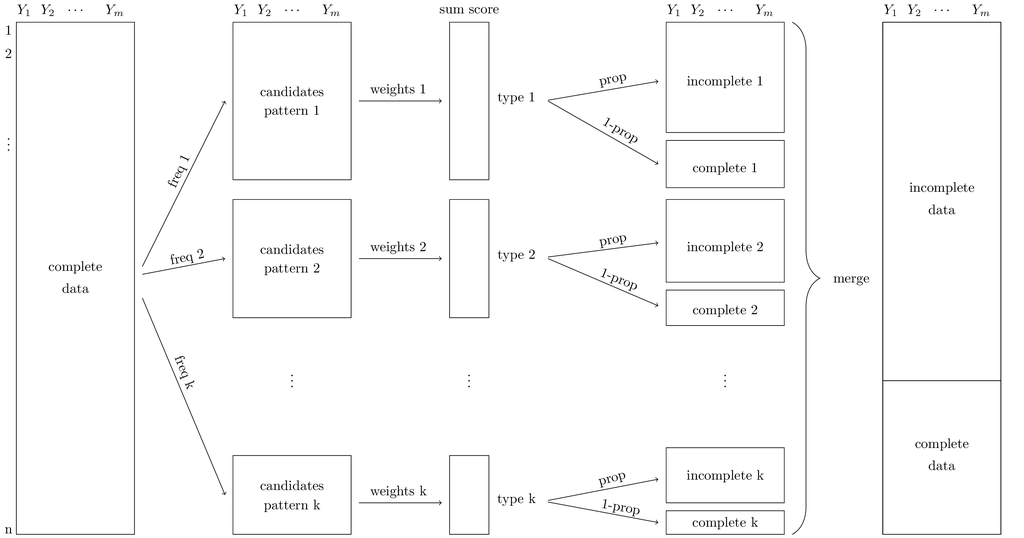

The core of the procedure lies in the **missingness patterns**. A missing data pattern is a particular combination of variables with missing values and variables that remain complete. Based on the number of missing data patterns $k$, the complete dataset is randomly divided into $k$ subsets. The size of these subsets may differ between the patterns using a so-called **frequency** vector.

All the data rows in a certain subset are candidates for a certain missing data pattern. Whether or not the candidates will become incomplete depends on a combination of factors.

One of those factors is the missingness **mechanism**. In case of MCAR missingness, all data rows have the same probability of being amputed. For MAR and MNAR missingness, we will use so-called **weighted sum scores**. In essence, MAR misingness occurs when the information about the missing data is in the observed data. In case of MNAR missingness, the information about the missing data is missing itself. For a discussion of how these mechanisms interact with observed data, see [Schouten and Vink (2021)](https://doi.org/10.1177/0049124118799376).

A weighted sum score is simply the outcome of a linear regression equation where the coefficients are determined by the user. We will discuss this a bit more below. For now it suffices to say that based on its weighted sum score, a candidate obtains a certain probability of being amputed. These probabilities are assigned using one of four **logistic distribution types**.

In the end, in every subset the specified **proportion** of data rows is made incomplete according to the missing data pattern of their candidacy. All subsets are merged and we now have one incomplete dataset, amputed according to the parameters specified by the user! We will now discuss these parameters in a bit more detail.

### Function `ampute` and its arguments

Although all parameters are connected, `ampute` provides a way to manipulate the missing data generation procedure without influencing other parameters. Figure 2 shows the most important arguments and the order in which we will discuss them.

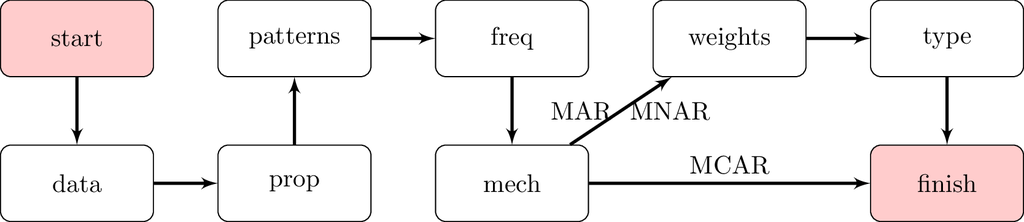

In short, `ampute`’s arguments are used for the following:

1. data: feed the function the complete dataset
2. prop: define the missingness proportion
3. patterns: specify the missing data patterns
4. freq: specify the relative occurrence of these patterns
5. mech: choose between a MCAR, MAR or MNAR mechanism
6. weights: specify weights for the calculation of weighted sum scores
7. type: choose a RIGHT, MID, TAIL or LEFT logistic distribution function

Use the help function to read `ampute`’s documentation. The function is available in multiple imputation package [**mice**](https://github.com/stefvanbuuren/mice).

```r
library("mice")
help(ampute)
```

#### Data

The first argument `data` is an input argument for a complete dataset. In this tutorial, as in many simulation studies, we will randomly generate a dataset to be our complete dataset. Here, we will use function `mvrnorm` from R-package **MASS** to sample from a multivariate normal distribution.

```r
set.seed(2016)
testdata <- as.data.frame(MASS::mvrnorm(n = 10000,
                                        mu = c(10, 5, 0),
                                        Sigma = matrix(data = c(1.0, 0.2, 0.2,
                                                                0.2, 1.0, 0.2,
                                                                0.2, 0.2, 1.0),
                                                       nrow = 3,
                                                       byrow = T)))
summary(testdata)
```

```
##        V1               V2               V3
##  Min.   : 6.346   Min.   :0.9789   Min.   :-3.799124
##  1st Qu.: 9.317   1st Qu.:4.3199   1st Qu.:-0.690542
##  Median :10.003   Median :4.9963   Median :-0.009941
##  Mean   : 9.998   Mean   :4.9973   Mean   : 0.000759
##  3rd Qu.:10.677   3rd Qu.:5.6759   3rd Qu.: 0.673069
##  Max.   :13.770   Max.   :8.6579   Max.   : 3.810729
```

We can immediately generate missing values by calling `ampute`. The resulting object is of class `mads` and contains the default values that are used as arguments. It is important to know that the incomplete dataset is stored under object `amp` in class `mads`.

```r
result <- ampute(data = testdata)
class(result)
```

```
## [1] "mads"
```

```r
head(result$amp)
```

```
##          V1       V2         V3
## 1        NA 6.018999  0.3681981
## 2  9.668991 4.391821 -1.1127595
## 3 10.273415 4.662521  0.1796964
## 4 10.124800 4.055544         NA
## 5        NA 7.171578  1.7141378
## 6 10.803311 5.038649         NA
```

Apart from the argument values and the incomplete dataset, the `mads` object contains the assigned subset for each data row (`cand`), the weighted sum scores (`scores`) and the original data (`data`).

```r
names(result)
```

```
##  [1] "call"     "prop"     "patterns" "freq"     "mech"     "weights"
##  [7] "cont"     "std"      "type"     "odds"     "amp"      "cand"
## [13] "scores"   "data"
```

We can quickly investigate the incomplete dataset with function `md.pattern`, where the resulting visualization shows the missing data in red and the observed data in blue. The first row always shows the complete cases, of which we have approximately 50%. Each subsequent row depicts a specific missing data pattern. By default, `ampute` generates missing values in each variable. Note that because `md.pattern` sorts the columns in increasing order of missing data proportion, the variables are displayed in a different order than in the dataset itself.

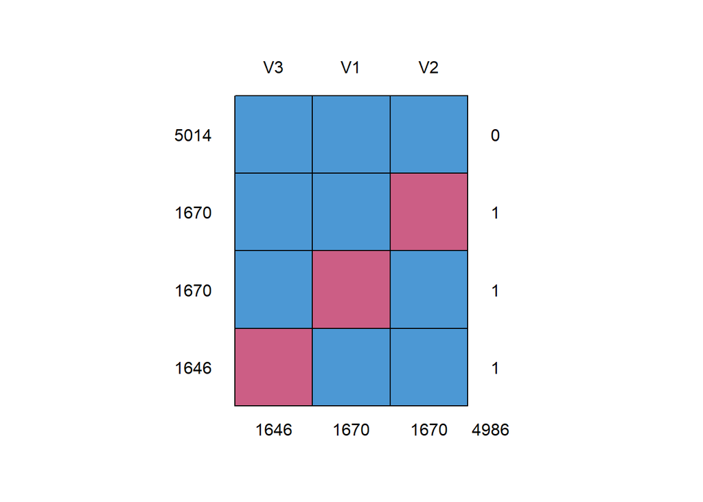

```
##        V3   V1   V2
## 5014    1    1    1    0
## 1670    1    1    0    1
## 1670    1    0    1    1
## 1646    0    1    1    1
##      1646 1670 1670 4986
```

```r
md.pattern(result$amp)
```

#### Prop

The argument `prop` specifies the **proportion** of incomplete rows. As a default, the missingness proportion is 0.5:

```r
result$prop
```

```
## [1] 0.5
```

A proportion of 0.5 means that 50% of the data rows will have missing values. This is not the same as the proportion of missing cells, because incomplete cases will still have some observed values for some variables. The number of missing cells therefore depends on the missing data patterns that are specified.

To specify the proportion of missing cells, additional argument `bycases` should be set to `FALSE`.

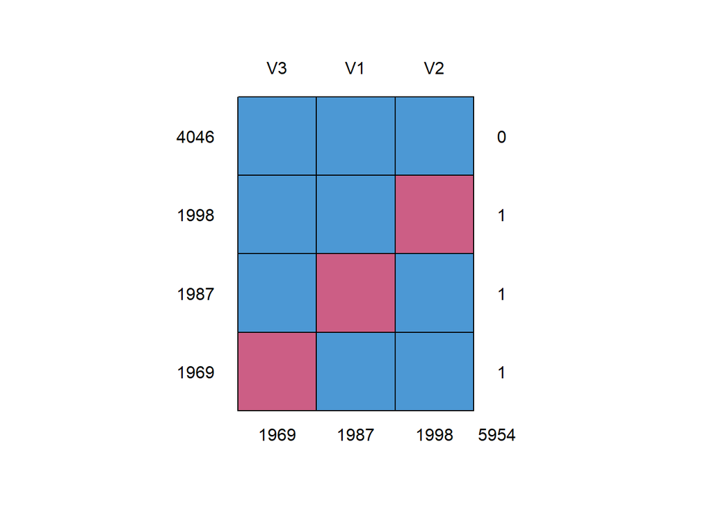

```
##        V3   V1   V2
## 4046    1    1    1    0
## 1998    1    1    0    1
## 1987    1    0    1    1
## 1969    0    1    1    1
##      1969 1987 1998 5954
```

```r
result <- ampute(testdata, prop = 0.2, bycases = FALSE)
md.pattern(result$amp)
```

As the `testdata` contains 10000 * 3 = 30000 cells, a missing data proportion of 0.2 means that approximately 6000 cells will become missing. As the visualization shows, this is indeed the case. In combination with the current set of missing data patterns, the resulting proportion of incomplete cases is:

```r
result$prop
```

```
## [1] 0.6
```

#### Patterns

The core idea of `ampute` is the generation of missing data **patterns**. Each pattern is a combination of missingness on specific variables while other variables remain complete. For example, someone could have forgotten to fill in the last page of a questionnaire, which results in missing values for a specific set of questions/variables. Or a participant misses one or more waves in a longitudinal study. Thus, each pattern is a specific combination of incomplete and complete variables.

The `patterns` argument uses a matrix to define these pattern. In this matrix, the patterns are placed on the rows and the variables on the columns. The value `0` is used for variables that should have missing values and `1` is used for complete variables.

```r
mypatterns <- result$patterns
mypatterns
```

```
##   V1 V2 V3
## 1  0  1  1
## 2  1  0  1
## 3  1  1  0
```

By default, the number of patterns equals the number of variables, where in each pattern one variable contains missing values. Note that as a result, there are no cases with missing values on more than one variable. A case either has missingness on V1, V2 or V3 or remains complete.

We can manipulate the matrix by changing the values or by adding rows. For example, we can change the matrix by creating a missingness pattern where cases have missing values in V1 and V2 but not on V3 (pattern 2). Furthermore, we will add a fourth missing data pattern that generates missingness in V1 and V3.

```r
mypatterns[2, 1] <- 0
mypatterns <- rbind(mypatterns, c(0, 1, 0))
mypatterns
```

```
##   V1 V2 V3
## 1  0  1  1
## 2  0  0  1
## 3  1  1  0
## 4  0  1  0
```

Then, we again call the amputation procedure with the desired patterns matrix as its third argument. We inspect the result with the `md.pattern` function.

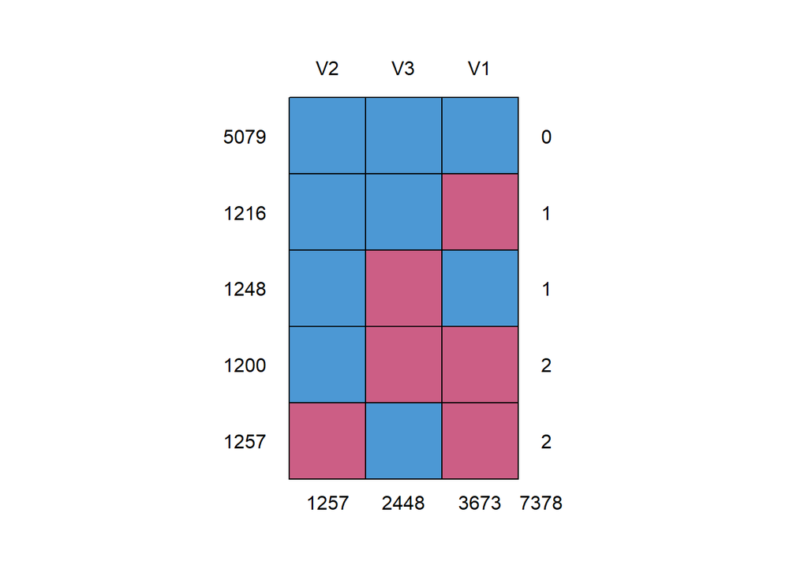

```
##        V2   V3   V1
## 5079    1    1    1    0
## 1216    1    1    0    1
## 1248    1    0    1    1
## 1200    1    0    0    2
## 1257    0    1    0    2
##      1257 2448 3673 7378
```

```r
result <- ampute(testdata, patterns = mypatterns)
md.pattern(result$amp)
```

#### Freq

As explained before, the amputation procedure divides the complete dataset into multiple subsets. The number of these subsets is determined by the number of patterns. The size of the subsets, and therefore the relative occurrence of the missing data patterns, can be determined with a **frequency** vector.

Argument `freq` is a vector with values between 0 and 1. The number of values determines the number of subsets and must be equal to the number of patterns.

```r
result$freq
```

```
## [1] 0.25 0.25 0.25 0.25
```

By default, the frequency vector has values of equal size (1/number of patterns). This means that all four subsets will have approximately the same size. We can adapt the frequency vector, for instance such that subset one becomes much larger than the other subsets.

```r
myfreq <- c(0.7, 0.1, 0.1, 0.1)
```

Note that the frequency values should always sum to 1.0 in order to divide all the cases over the subsets.

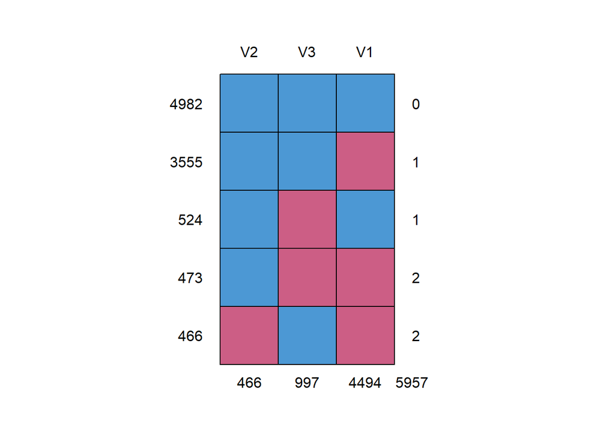

```
##       V2  V3   V1
## 4982   1   1    1    0
## 3555   1   1    0    1
## 524    1   0    1    1
## 473    1   0    0    2
## 466    0   1    0    2
##      466 997 4494 5957
```

```r
result <- ampute(testdata, freq = myfreq, patterns = mypatterns)
md.pattern(result$amp)
```

As the visualization shows, there are now four missing data patterns and the first pattern occurs 7 times as often as the other three patterns.

#### Mech

At this point in the procedure, we are able to generate missing data with a specified proportion, the missingness patterns of interest and in the desired relative occurence of those patterns.

We will now decide what kind of missingness **mechanism** we will implement. As said before, there are three mechanisms: MCAR, MAR and MNAR. In case of MCAR missingness, all data rows have the same probability of being amputed. With MAR misingness, the information about the missing data is in the observed data and with MNAR missingness, the information about the missing data is missing itself. We refer to [Schouten and Vink (2021)](https://doi.org/10.1177/0049124118799376) for a more thorough discussion of missingness mechanisms.

Argument `mech` in function `ampute` is a string with either `MCAR`, `MAR` or `MNAR`. As a default:

```r
result$mech
```

```
## [1] "MAR"
```

#### Weights

For MAR and MNAR mechanisms, we calculate a **weighted sum score** for all data rows. This calculation depends on pre-specified `weights` which are manipulated by the user through a matrix. The weights differ per pattern, and therefore, similar to the patterns matrix, the weights matrix contains the patterns on the rows and the variables on the columns ($k$ by $m$).

A weighted sum score is simply the outcome of a linear regression equation where the coefficients are the values of the weights matrix. When data row $i$ is a candidate for pattern $k$, the weighted sum score is therefore:

$$\begin{equation*}
wss_i = w_{k,1} \cdot y_{1,i} + w_{k,2} \cdot y_{2,i} + ... + w_{k,m} \cdot y_{m,i},
\end{equation*}$$

where $\{y_{1,i}, y_{2,i}, ..., y_{m,i}\}$ is the set of variable values of case $i$ and $\{w_{k,1}, w_{k,2}, ..., w_{k,m}\}$ are the pre-specified weights on row $k$ of the weights matrix. In our example, $m=3$ and $k\in\{1, 2, 3, 4\}$ because there are three variables and four missing data patterns.

In general, larger weights will give higher sum scores than smaller weights. For instance, if variables V1 and V2 have weights 4 and 2 respectively, V1’s influence on the sum scores is twice as large as that of V2. Note that the influence of the weights is relative; weight values of 0.4 and 0.2 will have the same effect.

Note that the direction of the weights is important as well. A positive weight will increase the weighted sum score while a negative weight will decrease it.

Note as well that each pattern receives its own weights and that the comparison of weights will happen within a pattern and not between patterns. For instance, variable V1 can have a weight of 4 in the first pattern, but a weight of -0.2 in the second pattern.

```r
result$weights
```

```
##   V1 V2 V3
## 1  0  1  1
## 2  0  0  1
## 3  1  1  0
## 4  0  1  0
```

By default, the weights matrix assigns values of `1` to the variables that remain complete in a certain pattern, and `0` to variables that will become incomplete. As such, the default weights matrix contains a MAR mechanism where every variable has the same influence.

Instead, for pattern 1, we can give variable V2 a larger weight than variable V3.

```r
myweights <- result$weights
myweights[1, ] <- c(0, 0.8, 0.4)
```

By choosing the values 0.8 and 0.4, variable V2 is weighted twice as much as variable V3. For pattern 3, we will weight variable V1 thrice as much as variable V2.

```r
myweights[3, ] <- c(3.0, 1.0, 0)
myweights
```

```
##   V1  V2  V3
## 1  0 0.8 0.4
## 2  0 0.0 1.0
## 3  3 1.0 0.0
## 4  0 1.0 0.0
```

The weights matrix is very powerful, because the user determines which variables determine the missingness (by a non-zero value) and which variables do not (by assigning a 0). As such, the weights matrix can also be used to switch from MAR to MNAR missingness, or even to create a combined mechanism.

We can see this when we change the `mech` argument to `MNAR`. It turns out that `ampute` then uses a weighs matrix that shows `1` for all variables that should become incomplete according to the patterns matrix (`0` in the patterns matrix).

```r
result <- ampute(testdata, freq = myfreq,
                 patterns = mypatterns, mech = "MNAR")
result$patterns
```

```
##   V1 V2 V3
## 1  0  1  1
## 2  0  0  1
## 3  1  1  0
## 4  0  1  0
```

```r
result$weights
```

```
##   V1 V2 V3
## 1  1  0  0
## 2  1  1  0
## 3  0  0  1
## 4  1  0  1
```

#### Type

Before we inspect the results of the weights matrix, we will quickly discuss the `type` argument in `ampute`. Here, we refer to the type of logistic probability distribution that is applied to the weighted sum scores, as shown in Figure 3. In `ampute`, these types can be called by setting `cont == TRUE` (this is by default the case) and then setting argument `type` to `LEFT`, `MID`, `RIGHT` or `TAIL`.

With `RIGHT` missingness, cases with high weighted sum scores will have a larger probability of becoming incomplete. With a left-tailed (LEFT), centered (MID) or both-tailed (TAIL) missingness type, larger probabilities are assigned to the candidates with low, average or extreme weighted sum scores respectively.

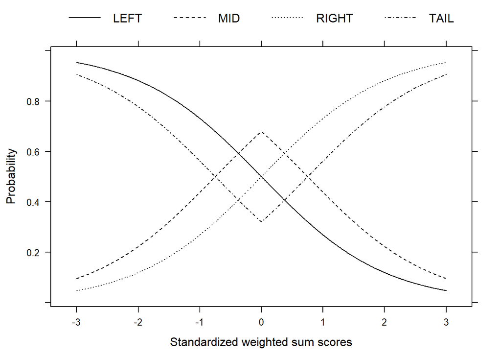